# Craft-Cans Case Study

Arturo Casillas & Kevin Dickens

October 6, 2017

# Abstract

This study seeks to evaluate the distribution of beer and certain beer characteristics across the United States and answer questions important to the relationships between those characteristics and the spatial distribution. The goal is to show the distribution of breweries across the united states, discuss correlation between the primary beer characteristics of ABV and IBU, and begin to explore the spatial relationships between breweries and beer characteristics.

# Introduction

In recent years the craft brewery movement has exploded across the United States. New breweries open every month across the nation and they come in many shapes, sizes, and forms from the microbrewery that primarily focuses on brewing beer to bars known as brewpubs who craft their own beer. The products that these establishments offer vary in many ways from packaging (cans versus bottles), to alcohol content, to style and bitterness. At the end of the day, they all manufacture beer. Of particular interest to this study are the relationships of canned craft beer breweries and the common beer characteristics. Do these characteristics show any relationships spatially or statistically? This study hopes to answer that basic question and provide a foundation for future research on the topic.

Of particular interest to the researchers requesting the analysis and those involved in the study are the spatial relationships and distributions of the canned craft beer movement. This study will look at how the breweries are distributed across the country and look at the spatial distributions of other beer characteristics to better understand trends and popularity of various beer styles. The spatial interpretation of data will inform readers of hot spots of craft brewery activity.

This study will also perform basic statistical analysis to better understand and interpret the both the spatial data and the underlying canned craft beer data as well. The findings will inform readers on the distributions of the data and allow them to look at the included maps to determine which states lie above or below median values as well as determine underlying relationships between such characteristics as alcohol by volume and international bitterness units.

Fundamentally, this study will seek to answer the following questions:

- How many breweries are in each state?
- What is the median ABV and IBU for each state?
- What is the spatial distribution of the data of interest?
- Are there any statistical or spatial relationships between the variables presented in the data?

## Scope

The scope of this analytical research is limited to the data originally provided by the requestor. As such the scope of the data pertains to U.S. domestic craft breweries that produce a canned beer product no later than 2015. It is unclear if this data contains all craft breweries that create a brewed product, or only a sample. The scope is further limited to only the 50 States and the District of Columbia. No U.S. territories are included in the underlying data.

# Data

This section will describe the original data and discuss methods used to convert the raw data into a tidy dataset ready for analysis. These steps are crucial for replication of the analysis as the raw data contained several anomalies which could prevent replication of the analysis presented later.

## About the Data

For more information on the raw data, see the codebook [here.](https://github.com/TeamBreach/CaseStudy1/blob/master/Codebook.md)

### Source

To prepare the data for analysis, variable names are altered for clarity and to minimize merging issues. The beers and breweries are linked by a unique numeric ID (Brew_ID), so no assumptions or algorithm was needed to combine the tables.

-View the structure of the original data. Expand below to see details.

-Prepare the data for merging, such as rename columns. Expand below to see details.

-Merged to create a single table, details below.

-Perform a spot check for integrity, view the first six rows

...

| Brew_ID | Beer_Name | Beer_ID | ABV | IBU | Style | Ounces |
| --- | --- | --- | --- | --- | --- | --- |
| 1 | Get Together | 2692 | 0.045 | 50 | American IPA | 16 |
| 1 | Maggie's Leap | 2691 | 0.049 | 26 | Milk / Sweet Stout | 16 |
| 1 | Wall's End | 2690 | 0.048 | 19 | English Brown Ale | 16 |
| 1 | Pumpion | 2689 | 0.06 | 38 | Pumpkin Ale | 16 |
| 1 | Stronghold | 2688 | 0.06 | 25 | American Porter | 16 |
| 1 | Parapet ESB | 2687 | 0.056 | 47 | Extra Special / Strong Bitter (ESB) | 16 |

| Brewery_Name | City | State |
| --- | --- | --- |
| NorthGate Brewing | Minneapolis | MN |
| NorthGate Brewing | Minneapolis | MN |
| NorthGate Brewing | Minneapolis | MN |
| NorthGate Brewing | Minneapolis | MN |
| NorthGate Brewing | Minneapolis | MN |
| NorthGate Brewing | Minneapolis | MN |

-Perform a spot check for integrity, view the lasts six rows

...

| Brew_ID | Beer_Name | Beer_ID | ABV | IBU | Style | Ounces |
| --- | --- | --- | --- | --- | --- | --- |
| 556 | Pilsner Ukiah | 98 | 0.055 | NA | German Pilsener | 12 |
| 557 | Heinnieweisse Weissebier | 52 | 0.049 | NA | Hefeweizen | 12 |
| 557 | Snapperhead IPA | 51 | 0.068 | NA | American IPA | 12 |
| 557 | Moo Thunder Stout | 50 | 0.049 | NA | Milk / Sweet Stout | 12 |
| 557 | Porkslap Pale Ale | 49 | 0.043 | NA | American Pale Ale (APA) | 12 |
| 558 | Urban Wilderness Pale Ale | 30 | 0.049 | NA | English Pale Ale | 12 |

| Brewery_Name | City | State |
| --- | --- | --- |
| Ukiah Brewing Company | Ukiah | CA |
| Butternuts Beer and Ale | Garrattsville | NY |
| Butternuts Beer and Ale | Garrattsville | NY |
| Butternuts Beer and Ale | Garrattsville | NY |
| Butternuts Beer and Ale | Garrattsville | NY |
| Sleeping Lady Brewing Company | Anchorage | AK |

### Data Integrity

-Table of numeric missing values

| Brew_ID | Beer_Name | Beer_ID | ABV | IBU | Style | Ounces | Brewery_Name | City | State |
| --- | --- | --- | --- | --- | --- | --- | --- | --- | --- |
| 0 | 0 | 0 | 62 | 1005 | 0 | 0 | 0 | 0 | 0 |

-Table of character missing values

| Brew_ID | Beer_Name | Beer_ID | ABV | IBU | Style | Ounces | Brewery_Name | City | State |
| --- | --- | --- | --- | --- | --- | --- | --- | --- | --- |
| 0 | 0 | 0 | NA | NA | 5 | 0 | 0 | 0 | 0 |

### Add Region & Division

R contains additional region and division data per state in the package 'datasets'. These data are from a 1977 report from the chamber of commerce. The state classifications for region and division have not changed. Prior to June 1984 however, the Midwest Region was designated as the North Central Region. These data were added to expand analysis options and segmenting the states and cities geographically.

# Analysis

### Breweries and Syles

There are 558 unique breweries and 100 different styles. The most popular style is 'American IPA' followed by 'American Pale Ale'. These two styles combined constitute 27.8% of all 2410 beers. Furthermore, eight of the most popular styles also have 'American' in the name. Only Nevada's and New Hampshire's most popular styles do not have 'American' in the name, being 'Saison' and 'Witbier' respectively. In addition, California, Colorado, and Michigan house the greatest number of breweries.

-23 of the 100 unique styles are 'American'. However, these 23 styles constitute 62% of all craft cans. Calculations may be confirmed below. Only 37 out of 2410 beers have 'America' in their name.

-The total number of breweries per state is shown below. The data does not show Puerto Rico, but it appears that every state and Washington DC have at least one Brewery.

| AK | AL | AR | AZ | CA | CO | CT | DC | DE | FL | GA | HI | IA | ID | IL | IN | KS | KY | LA | MA |
| --- | --- | --- | --- | --- | --- | --- | --- | --- | --- | --- | --- | --- | --- | --- | --- | --- | --- | --- | --- |
| 7 | 3 | 2 | 11 | 39 | 47 | 8 | 1 | 2 | 15 | 7 | 4 | 5 | 5 | 18 | 22 | 3 | 4 | 5 | 23 |

| MD | ME | MI | MN | MO | MS | MT | NC | ND | NE | NH | NJ | NM | NV | NY | OH | OK | OR | PA | RI |
| --- | --- | --- | --- | --- | --- | --- | --- | --- | --- | --- | --- | --- | --- | --- | --- | --- | --- | --- | --- |
| 7 | 9 | 32 | 12 | 9 | 2 | 9 | 19 | 1 | 5 | 3 | 3 | 4 | 2 | 16 | 15 | 6 | 29 | 25 | 5 |

| SC | SD | TN | TX | UT | VA | VT | WA | WI | WV | WY |
| --- | --- | --- | --- | --- | --- | --- | --- | --- | --- | --- |
| 4 | 1 | 3 | 28 | 4 | 16 | 10 | 23 | 20 | 1 | 4 |

-Map of total number of breweries per state. Colorado stands out as having many more breweries than its neighbors.

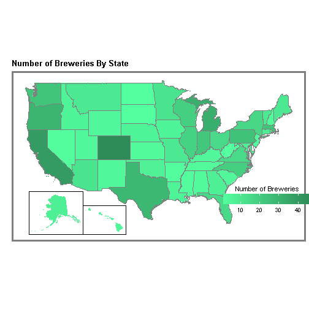

### ABV and IBU Summary

-Summary Statistics for ABV below

| Min. | 1st Qu. | Median | Mean | 3rd Qu. | Max. | NA's |
| --- | --- | --- | --- | --- | --- | --- |
| 0.001 | 0.05 | 0.056 | 0.05977 | 0.067 | 0.128 | 62 |

-The 10 most alcoholic beers are listed below

| Beer_ID | State | Beer_Name | ABV | IBU | Brewery_Name | City | Style |
| --- | --- | --- | --- | --- | --- | --- | --- |
| 2565 | CO | Lee Hill Series Vol. 5 - Belgian Style Quadrupel Ale | 0.128 | NA | Upslope Brewing Company | Boulder | Quadrupel (Quad) |
| 2685 | KY | London Balling | 0.125 | 80 | Against the Grain Brewery | Louisville | English Barleywine |
| 2621 | IN | Csar | 0.120 | 90 | Tin Man Brewing Company | Evansville | Russian Imperial Stout |
| 2564 | CO | Lee Hill Series Vol. 4 - Manhattan Style Rye Ale | 0.104 | NA | Upslope Brewing Company | Boulder | Rye Beer |
| 2574 | NY | 4Beans | 0.100 | 52 | Sixpoint Craft Ales | Brooklyn | Baltic Porter |
| 1036 | CA | Lower De Boom | 0.099 | 92 | 21st Amendment Brewery | San Francisco | American Barleywine |
| 1674 | CA | Chaotic Double IPA | 0.099 | 93 | Manzanita Brewing Company | Santee | American Double / Imperial IPA |
| 904 | CA | Ex Umbris Rye Imperial Stout | 0.099 | 85 | Hess Brewing Company | San Diego | American Double / Imperial Stout |
| 1561 | CA | Double Trunk | 0.099 | 101 | The Dudes' Brewing Company | Torrance | American Double / Imperial IPA |
| 6 | CO | GUBNA Imperial IPA | 0.099 | 100 | Oskar Blues Brewery | Longmont | American Double / Imperial IPA |

-Summary statistics for IBU

| Min. | 1st Qu. | Median | Mean | 3rd Qu. | Max. | NA's |
| --- | --- | --- | --- | --- | --- | --- |
| 4 | 21 | 35 | 42.71 | 64 | 138 | 1005 |

-The 10 most bitter beers

| Beer_ID | State | Beer_Name | ABV | IBU | Brewery_Name | City | Style |
| --- | --- | --- | --- | --- | --- | --- | --- |
| 980 | OR | Bitter Bitch Imperial IPA | 0.082 | 138 | Astoria Brewing Company | Astoria | American Double / Imperial IPA |
| 1676 | VA | Troopers Alley IPA | 0.059 | 135 | Wolf Hills Brewing Company | Abingdon | American IPA |
| 2067 | MA | Dead-Eye DIPA | 0.090 | 130 | Cape Ann Brewing Company | Gloucester | American Double / Imperial IPA |
| 2440 | OH | Bay of Bengal Double IPA (2014) | 0.089 | 126 | Christian Moerlein Brewing Company | Cincinnati | American Double / Imperial IPA |
| 15 | MN | Abrasive Ale | 0.097 | 120 | Surly Brewing Company | Brooklyn Center | American Double / Imperial IPA |
| 1111 | VT | Heady Topper | 0.080 | 120 | The Alchemist | Waterbury | American Double / Imperial IPA |
| 379 | VT | Heady Topper | 0.080 | 120 | The Alchemist | Waterbury | American Double / Imperial IPA |
| 2123 | TX | More Cowbell | 0.090 | 118 | Buffalo Bayou Brewing Company | Houston | American Double / Imperial IPA |
| 1492 | CA | Blazing World | 0.065 | 115 | Modern Times Beer | San Diego | American Amber / Red Ale |
| 851 | DC | On the Wings of Armageddon | 0.092 | 115 | DC Brau Brewing Company | Washington | American Double / Imperial IPA |

ABV and IBU are probably related, but it is not obvious at first glance.

-Barplot of median ABV and IBU per state

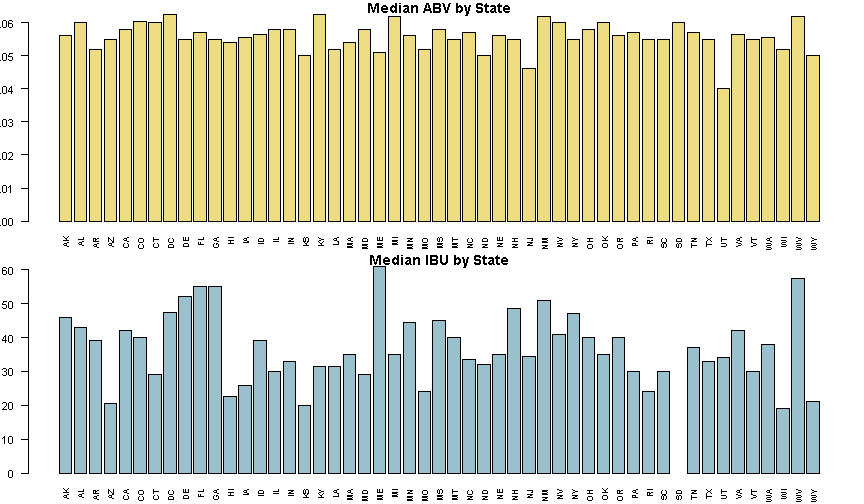

-Map of median ABV per state below. Utah is the only state that stands out as having a particularly low median ABV at only 4.0%. In contrast, KY and Washington DC have the highest median ABV at 6.25%.

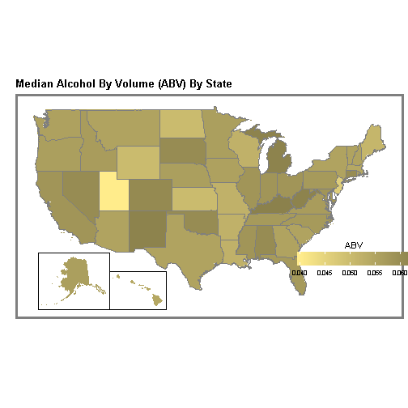

-Map of median IBU per state. The state with the lowest median IBV score is Wisconsin with only a 19 median IBV. The highest is Maine with a Median of 61.

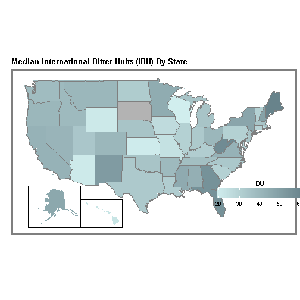

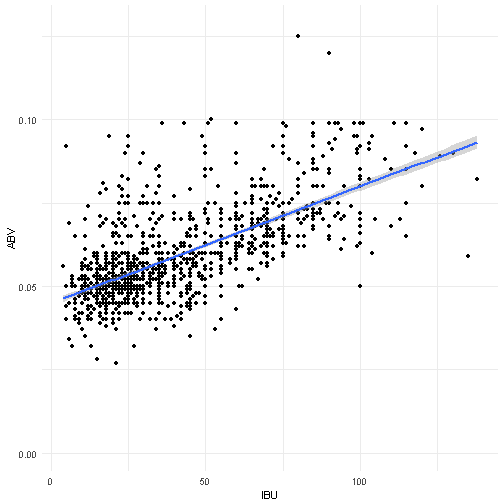

# Summary and Conclusions

## Spatial Summary and Conclusions

As one can see, craft canned breweries are roughly equally distributed across the country with a few notable exceptions. Colorado contains more craft breweries than any other single state. The west coast trends higher than the rest of the country and the upper Midwest and St. Lawrence River corridor shows slightly higher than usual distribution. In order to evaluate why, we'd need more data but reasonable assumptions for the west coast and the St. Lawrence corridor stem from the large population in those regions. Colorado remains an anomaly at this point as commonly available data do not give any meaningful explanation to this phenomenon.

In order to discuss measures of popularity or preference we must note that the only data in the given dataset to derive a measure of these descriptive terms stems from the number of beers brewed of a particular style, or with significant deviations from the median ABV or IBU. A better statistic would be to look at consumption patterns rather than brewing patterns as it is possible to brew beer that no one drinks or is otherwise considered unpopular.

There appear to be no easily quantifiable spatial distribution trends for ABV oby state. The central states away from the coasts appear higher overall but do not deviate from the median significantly enough to note a trend. Utah stands out as the sole anomaly with significantly lower ABV than the surrounding states, especially since it rests central to a cluster of higher than typical ABV states. This could be due to government intervention by the state or from societal differences given the large Mormon population in Utah.

Certain regions stand out as preferring different levels of bitterness as shown by the map of IBU by state. The Pacific Coast and northwestern states prefer a moderate to high level of bitterness while the central plains states appear to prefer lower bitterness. Both the southeastern and northeastern states seemingly prefer higher bitterness levels as well, but not as consistently as the west and northwest. Of note is the absence of data for South Dakota. Without further data we can only assume this is a regional preference and not some other underlying social, governmental, or societal difference.

## Statistical Summary and Conclusions

Alcohol by volume, abbreviated as ABV, appears to be relatively consistent among the styles and among states. Beers brewed out of Utah are the only ones whose median ABV deviate substantially from the rest of the states. International bitterness units, abbreviated IBU, varies much more among states and among styles. However, much of the data is missing which could account for the additional variance we are seeing. The most bitter beers are American Double IPAs. It appears that 'American' beer styles, like American IPA and APA, are very popular and make up a disproportionate share of all craft canned beers that are brewed. In fact, American IPA and American Pale Ale alone make up 27.8% of all canned beers that were surveyed. However, only 37 of the 2410 beers in the sample actually have 'American' in the title making it likely that these styles are brewed out of popularity and not as a marketing tactic.

## Additional Questions

During analysis of the data the researchers discussed many additional questions. These questions ultimately did not see resolution in this study due to time or data constraints but could prove fruitful areas of research in the immediate future, particularly for those seeking to open a brewery in the near term or analyzing the common traits or popularity of various beer styles. Questions include:

- What is the most popular beer style by Region/City?
- Which, if any, American styles are popular outside of the United States?
- What separates an American beer style from its nonAmerican counterpart?
- What are the median ABV/IBU by Beer Style?
- Is there any relationship to ABV or IBU and the size of the beer (ounces)?
- Why is there a correlation between ABV and IBU? What causes it?
- What is the best place to open a canned craft beer brewery?
- What is the worst place to open a canned craft beer brewery?
- This data focused on canned beer, what about bottled beer or aggregate of all craft beer?
- What is driving the opening of so many breweries in Colorado?
- Utah shows significantly lower median ABV. Why?
- Are regions that grow more hops likely to prefer beer with a higher IBU?

In turn these questions would likely open up additional avenues of research as long as discoverable data exists to support that research.

### What's Next?

Leverage the current data to perform more analysis of distribution of various beer styles by state or region. Use of the city variable did not come up in this research but could create an added component to show true hotspots if added to the plot for the number of breweries.

Since the IBU data contained many blank fields, that data could be researched further to fill in wholes to ensure the data represented in this study truly reflects the actual median and maximum values. Additional data on actual volumes and sales of canned craft brew could show a better understanding of which styles are popular in various states and regions. Additionally, deeper statistical analysis could be performed with market analysis to better aid the industry as a whole and answer questions about optimal locations for new breweries and demand.

Styled with knitrBootstrap